# Statistical Test

[figure not shown]

# Introduction

**Audience:** Someone who has working knowledge of python and wants to learn the theory of statistical test (such as t-test and chi-square test) and how to run those test in Python.

**Prerequisite:** Introduction to Python

**Description:** This is the prerequisite of Hypothesis Testing in Python course, it mainly covers the theory of statistical test such as t-test and chi-squared test, and how to run these test in Python. Firstly, the theory will be shown and then examples will be shown.

## Packages and Data

In this pre-course, we will be using `pandas`, `scipy.stats` and `pingouin` packages.

```python
# Importing pandas, scipy.stats and pingouin

import pandas as pd

import scipy.stats as ss

import pingouin as pg
```

The datasets I will be using is `airquality_data` and `energy_data`stored in the `data` folder.

```python
# Load in the airquality_data and energy_data from the data folder
# using pandas package and read_csv function assign to the name airquality and energy respectively

airquality = pd.read_csv("../Data/airquality_data.csv")

energy = pd.read_csv("../Data/energy_data.csv")
```

We will look at the first 5 observations of `airquality` data

```python
# First 5 observations of airquality data

airquality.head()
```

```
##       ozone     solar_r  wind  temp  month  day
## 0  41.00000  190.000000   7.4    67      5    1
## 1  36.00000  118.000000   8.0    72      5    2
## 2  12.00000  149.000000  12.6    74      5    3
## 3  18.00000  313.000000  11.5    62      5    4
## 4  42.12931  185.931507  14.3    56      5    5
```

We will also look at the unique values in the `month` column of `airquality` data.

```python
# Find the unique values in month column

airquality['month'].unique()
```

```
## array([5, 6, 7, 8, 9], dtype=int64)
```

The `airquality_data` has 6 columns/variables, but we will be only focusing on two variables that are:

- **temp** - Maximum daily temperature in degrees Fahrenheit at LaGuardia Airport.
- **month** - Daily air quality measurements in New York from May to September in 1973.

Similarly, we can look at the first 5 observation of `energy` data as shown below:

```python
# First 5 observations of energy data

energy.head()
```

```
##    consumption       income  bedrooms adults  country
## 0  20603.44161  38397.80896         6      4  England
## 1  12210.23996  32742.29374         4      2  England
## 2  16236.10818  49932.84808         5      3  England
## 3  17406.05105  31932.01377         6      2  England
## 4  16413.74336  27745.42519         7      3    Wales
```

The `energy_data` has 5 columns/variables, but we will be only focusing on two variables that are:

- **bedrooms** - Number of bedrooms in the property.
- **adults** - The number of adults in the household.

Hence, we will look at the unique values in `adults` and `bedrooms` columns of `energy` data.

```python
# Find the unique values in the bedrooms column

energy['bedrooms'].unique()
```

```
## array([6, 4, 5, 7, 3, 8, 2, 1], dtype=int64)
```

```python
# Find the unique values in the adults column

energy['adults'].unique()
```

```
## array(['4', '2', '3', '1', '5 or more'], dtype=object)
```

# Learning Objectives

**The goal of this session is to learn about**

- The structure of the statistical test
- Hypothesis testing
- The critical value approach
- The p-value approach
- T-test
- Chi-squared test

# 1 Structure of the statistical test

Inferential statistics is all about making decisions about the value of a particular observation or measurement. One of the most commonly used methods for making such decisions is to perform a hypothesis test. In this section, we will cover several statistical test to aid in data inference.

There are seven steps to follow when you are using any statistical test:

1. State the null hypothesis $H_{0}$ and alternative hypothesis $H_{a}$
2. Decide the significance level, $\alpha$
3. Compute the observed test statistics
4. Determine the critical value
5. Determine the p-value
6. Determine the confidence interval
7. Interpret your results

# 2 Hypothesis testing

Any hypothesis test starts with the formulation of the null hypothesis which typically suggests that there is no statistical difference between groups and the alternative hypothesis suggests that there is a difference. Suppose we have two different medicines, the first medicine is in group A and the other is group B. We denote the mean of group A medicine as $\mu_{1}$ and the mean of group B medicine is denoted as $\mu_{2}$.

To find out if the mean of group A is different from the mean of group B we construct a two-sided test as shown below:

$$H_{0}: \mu_{1}= \mu_{2} ~~~~~ (vs) ~~~~~ H_{a}:\mu_{1} \neq \mu_{2}$$

To find out if the mean of group A is greater than the mean of group B we construct a right-tailed test (or one-sided test) as shown below:

$$H_{0}: \mu_{1}= \mu_{2} ~~~~~ (vs) ~~~~~ H_{a}:\mu_{1} \ge \mu_{2}$$

To find out if the mean of group A is less than the mean of group B we construct a left-tailed test (or one-sided test) as shown below:

$$H_{0}: \mu_{1}= \mu_{2} ~~~~~ (vs) ~~~~~ H_{a}:\mu_{1} \le \mu_{2}$$

After formatting your hypothesis you need to decide the significance level yourself (typically set to 5% or 1%). A significance level is a probability of rejecting the null hypothesis when it is true and it is denoted by $\alpha$. There are two approaches to make your decision of rejecting the null hypothesis. These are:

- The critical value approach
- The p-value approach

## 2.1 Quiz

### **Quiz**

When do we construct a two-sided test?

1. To find out if the mean of group A is greater than the mean of group B
2. To find out if the mean of group A is different from the mean of group B
3. To find out if the mean of group A is less than the mean of group B

Which statements show a one-sided test?

1. $H_{0}: \mu_{1}= \mu_{2} ~~~~~ (vs) ~~~~~ H_{a}:\mu_{1} \le \mu_{2}$
2. $H_{0}: \mu_{1}= \mu_{2} ~~~~~ (vs) ~~~~~ H_{a}:\mu_{1} \neq \mu_{2}$
3. $H_{0}: \mu_{1}= \mu_{2} ~~~~~ (vs) ~~~~~ H_{a}:\mu_{1} \ge \mu_{2}$

What approaches do we take when deciding on rejecting the null hypothesis?

1. Two-sided approach
2. Critical value approach
3. P-value approach

### **Show Answer**

When do we construct a two-sided test?

2. To find out if the mean of group A is different from the mean of group B

Which statements show a one-sided test?

1. $H_{0}: \mu_{1}= \mu_{2} ~~~~~ (vs) ~~~~~ H_{a}:\mu_{1} \le \mu_{2}$
2. $H_{0}: \mu_{1}= \mu_{2} ~~~~~ (vs) ~~~~~ H_{a}:\mu_{1} \ge \mu_{2}$

What approaches do we take when deciding on rejecting the null hypothesis?

2. Critical value approach
3. P-value approach

## 2.2 Critical Value approach

By applying the critical value approach it is determined whether or not the observed test statistic is more extreme than a defined critical value - the observed test statistic (calculated based on sample data) is compared to the critical value. The following three figures show a right-tailed test, a left tailed test, and a two-sided test. The figures represent an idealised model(not all models follow a normal probability curve, this one is considered ideal and useful to explain the theory).

For a right-tailed test, the null hypothesis is rejected when the observed test statistics value is greater than the critical value.

$$H_{0}: \mu_{1}= \mu_{2} ~~~~~ (vs) ~~~~~ H_{a}:\mu_{1} \ge \mu_{2}$$

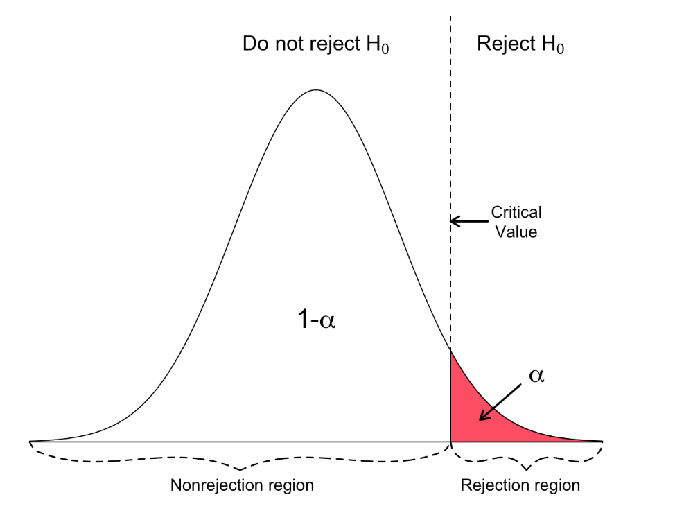

For a left-tailed test, the null hypothesis is rejected when the observed test statistics value is lower than the critical value.

$$H_{0}: \mu_{1}= \mu_{2} ~~~~~ (vs) ~~~~~ H_{a}:\mu_{1} \le \mu_{2}$$

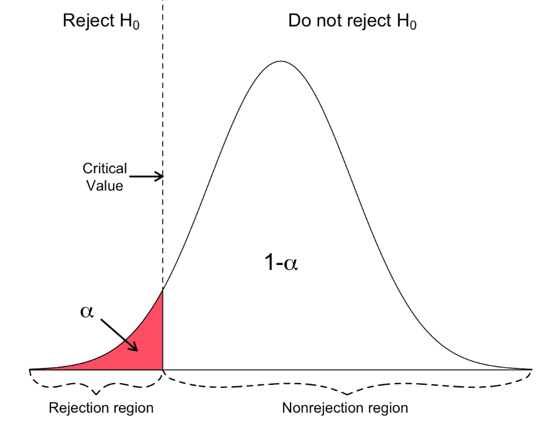

For a two-tailed test, the null hypothesis is rejected when the observed test statistics value is less than or greater than the critical values.

$$H_{0}: \mu_{1}= \mu_{2} ~~~~~ (vs) ~~~~~ H_{a}:\mu_{1} \neq \mu_{2}$$

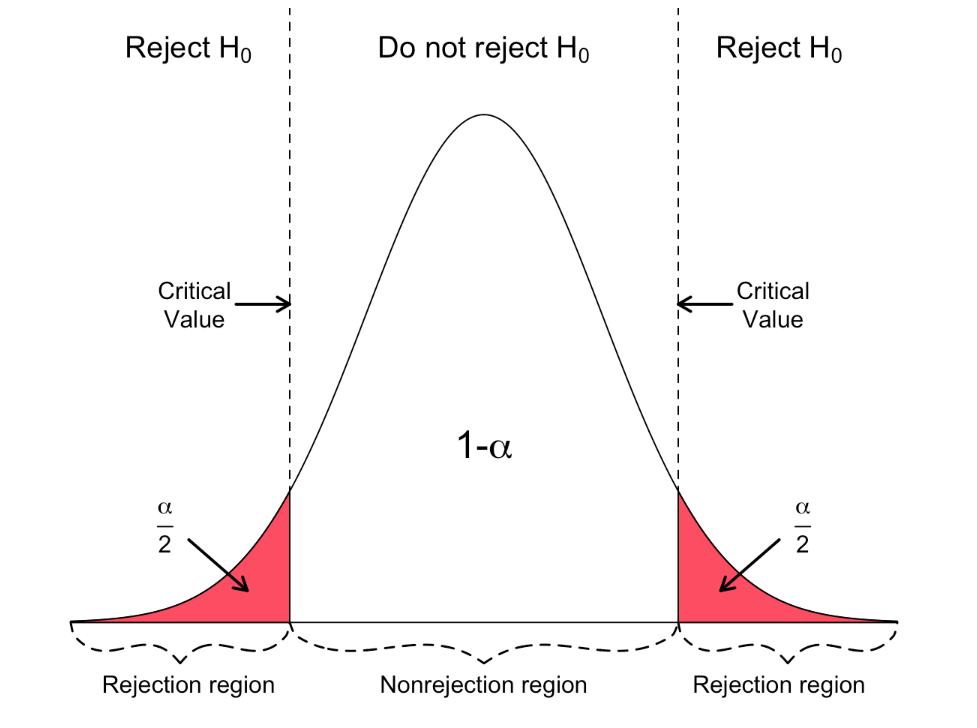

Symmetrical distributions like the t and z distributions have two tails. Asymmetrical distributions like the F and chi-square distributions have only one tail. This means that analyses such as ANOVA and chi-square test do not have a “one-tailed vs. two-tailed” option, because the distributions they are based on have only one tail.

### 2.2.1 Quiz

#### **Quiz**

What type of test is shown in the image below?

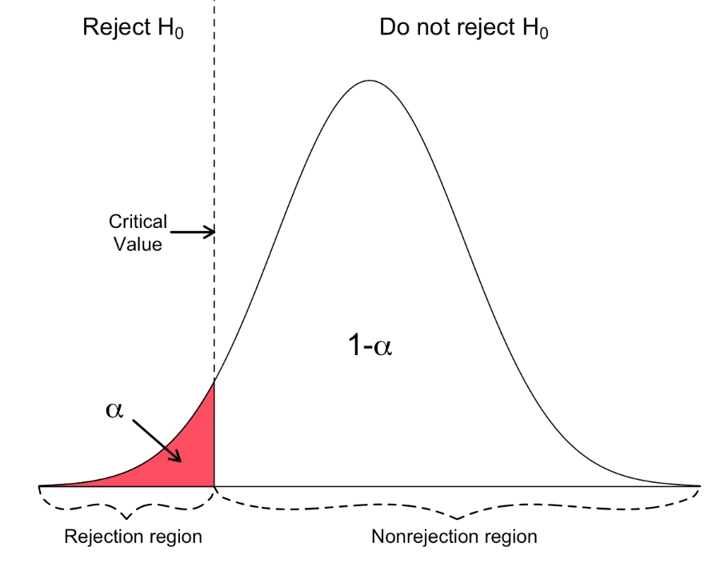

1. Two-tailed test
2. Left-tailed test
3. Right-tailed test

When do we reject the null hypothesis of two sided-test?

1. When the observed test statistics value is less than or greater than the critical values.
2. When the observed test statistics value is less than the critical value.
3. When the observed test statistics value is greater than the critical value.

#### **Show Answer**

What type of test is shown in the image below?

2. Left-tailed test

When do we reject the null hypothesis of two sided-test?

1. When the observed test statistics value is less than or greater than the critical values.

## 2.3 P-value Approach

A p-value is a probability of obtaining results as extreme as the observed results of a statistical hypothesis test, assuming that the null hypothesis is correct. The p-value is denoted as $p$ and it is used as an alternative to the critical value approach. If $p \le \alpha$ then we reject the null hypothesis and say the results are statistically significant. However, if $p \ge \alpha$ we do not reject the null hypothesis and thus say the results are not statistically significant.

### 2.3.1 Quiz

#### **Quiz**

When are results not statistically significant?

1. When we reject the null hypothesis
2. When we do not reject the null hypothesis
3. When we accept the alternative hypothesis

Using the p-value approach when do we reject the null hypothesis?

1. When the p-value is less than or equal to significance level ($p \le \alpha$)
2. When the p-value is greater than or equal to significance level ($p \ge \alpha$)
3. When the p-value is not equal to the significance level ($p \ne \alpha$)

#### **Show Answer**

When are results not statistically significant?

2. When we don’t reject the null hypothesis (saying accept the alternative hypothesis is not considered as best practice)

Using the p-value approach when do we reject the null hypothesis?

1. When the p-value is less than or equal to significance level ($p \le \alpha$)

# 3 Statistical test

One and two-sample test can be carried out in Python. The one-sample test allows us to compare the sample mean/proportion to the mean/proportion of the population, or to a hypothesised value, to determine if they are significantly different. However, the two-sample test is used to determine whether two sample means/proportions of different groups vary. In this course, we will be considering a two-sample independent t-test and chi-square independence test only. The table below is meant to serve as a general guide when deciding which statistical test to run.

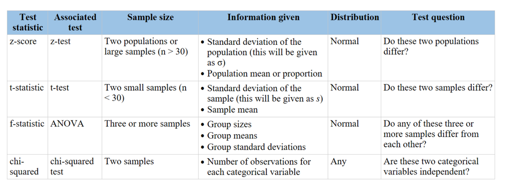

## 3.1 T-Test

A two-sample independent t-test is a statistical test to determine whether the mean values of two independent/unrelated groups are significantly different from one another when the population variance/standard deviation is unknown. The assumptions of the two-sample independent t-test are as follows:

- The data are continuous and follow the normal probability distribution.
- The variances of the two samples are equal (then Student’s independent t-test is used) and if the variance is unequal then (Welch’s independent t-test is used)
- The two samples are independent (if they are not independent then we use paired t-test)
- The sampling method for each group is simple random sampling.

We will be using the `airquality` dataset again to find out if the average temperature in June is significantly different from the average temperature in September. So, we will create two data frames that contains all observations in June and September respectively and then select the temperature column from both datasets as shown below:

```python
# Here we are filtering airquality data to get two data frames
# first consist of observations in June and second consist of observations in September

june = airquality[airquality['month'] == 6]

sep = airquality[airquality['month'] == 9]

# Then select the temperature column

temp_june = june['temp']

temp_sep = sep['temp']
```

**Step 1: Construct a two-tailed test where the null hypothesis and alternative hypothesis are shown below:**

$H_{0}:$ Mean temperature in June is the same as the mean temperature in September

$H_{a}:$ Mean temperature in June is different from the mean temperature in September

**Step 2: Choose your significance level $\alpha=0.05$ (typically it is 5% or 1%)**

```python
# Assigning significance level to be 0.05

alpha = 0.05
```

**Step 3: Run two-sided t-test by running one function as shown below:**

```python
# Run two-sided independent t-test where x and y needs to be an array-like or float
# parameter paired = False means the groups are independent
# parameter correction = auto means it will automatically use Welch t-test (variance unequal)
# our alpha is 0.05

t_test = pg.ttest(x=temp_june, y=temp_sep, paired=False, tail='two-sided',
                  correction='auto', confidence=0.95)

# Display the results
# by specifying the name of the variable
# or using print() function if you are using spyder

t_test
```

```
##                T  dof       tail  ...  cohen-d   BF10    power
## T-test  1.131764   58  two-sided  ...  0.29222  0.449  0.19959
##
## [1 rows x 8 columns]
```

> **Reminder:** If you are using Jupyter Notebook or RStudio then you can print your output by specifying the variable name however if you are using Spyder then you need to use the `print()` function to print output.

The function returns:

- **T-value:** the observed value of t statistics. We compare this observed value with the critical value to determine if there is a statistically significant difference between mean temperature in both months.
- **dof:** the degrees of freedom of an estimate, it is the number of independent pieces of information that went into calculating the estimate. It is used to calculate the critical value.
- **p-value:** the p-value of the test. If $p \le \alpha$ then we reject the null hypothesis and say the results are statistically significant.
- **95% confidence intervals:** is the estimated range of values that is likely to include an unknown population parameter. If the confidence interval does not contain the null hypothesis value, the results are statistically significant.
- **cohen-d:** the measure of effect size (we will cover this in the Hypothesis testing course)
- **power:** it is the achieved power of the test (we will cover this in the Hypothesis testing course)
- **BF10:** Bayes Factor of the alternative hypothesis

**Step 4: Critical value approach: Determine the critical value to compare with the observed test statistics.**

```python
# Finding the critical value using ss package
# for two-sided test our quantile is 1- alpha/2 where alpha is significance level
# it is a two-sided test that is why we divide it by 2 and then we specify the degrees of freedom (df)

t_critical = ss.t.ppf(q=1-alpha/2, df=58)

# Round the critical value to 3 decimal places
round(t_critical, 3)
```

```
## 2.002
```

The critical values are $\pm t_{\alpha/2,58}=\pm 2.002$. So, any value above $+2.002$ and below $-2.002$ is inside the rejection region which means if the value of observed t statistics is above $+2.002$ and/or below $-2.002$, then we reject the null hypothesis at a 5% significance level. However, if the value of observed t statistics is outside this range then it is called a non-rejection region because we do not reject the null hypothesis. We can construct the non-rejection region as shown below:

```python
# Constructing the Non-rejection region where any value above +2.002
# and any value below -2.002 is considered to be in the non-rejection region

non_rejection_region = print("−", round(t_critical,3), round(t_critical,3))
```

```
## − 2.002 2.002
```

```python
# Display the observed test statistic

t_test['T']
```

```
## T-test    1.131764
## Name: T, dtype: float64
```

The observed test statistic (t=1.132) is inside the non-rejection region. This suggests we cannot reject the null hypothesis at a 5% significance level.

**Step 5: P-value approach**

```python
# Display the p-value

t_test['p-val']
```

```
## T-test    0.262391
## Name: p-val, dtype: float64
```

The p-value is greater than $\alpha=0.05$, so there is not enough evidence to reject the null hypothesis at a 5% significance level. This shows that the difference in mean of temperatures in June and September is not statistically significant.

**Step 6: Determine the confidence interval**

```python
# Display the confidence interval

t_test['CI95%']
```

```
## T-test    [-1.69, 6.09]
## Name: CI95%, dtype: object
```

The 95% confidence interval is (-1.69, 6.09) does include the null value, zero, hence the average difference in temperature between both months is not statistically significant.

**Step 7: Interpret the results**

Overall, we cannot reject the null hypothesis at a 5% significance level which suggests that the difference in mean of temperatures in June and September is not statistically significant.

## 3.2 Chi-square Independence Test

The Chi-square ($\chi^2$) independence test is an inferential method to determine whether two variables are independent/unrelated to each other. The null hypothesis is that the distribution of one variable is independent of the distribution of another variable, and therefore not affected by its presence. The ($\chi^2$) independence test compares the observed frequencies in a contingency table with the expected frequencies, given the null hypothesis is true. The data must meet the following assumptions:

- There should be two categorical variables
- Two or more categories (groups) for each variable.
- Independence of observations. There is no relationship between the subjects in each group and the categorical variables are not “paired” in any way.
- Relatively large sample size where expected frequencies for each cell are at least 1 and expected frequencies should be at least 5 for the majority (80%) of the cells.

We will be using the `energy` data to find out if the number of bedrooms and adults living in that house are independent.

First, we construct the hypothesis:

$H_{0}:$ No association between the number of bedrooms and adults living in the house

$H_{a}:$ There is an association between the number of bedrooms and adults living in the house

Usually, after constructing a hypothesis we derive a contingency table of one categorical variable against another: adults vs bedrooms. However in `pingouin` package, the function `pingouin.chi2_independence()` gives three main outputs: observed contingency table expected contingency table and the chi-square test summary.

```python
# Using pingouin.chi2_independence get the expected, observed and stats

expected, observed, stats = pg.chi2_independence(data=energy, x='bedrooms', y='adults',
                                                 correction=False)
```

[output not shown]

As you can see the warning appears, this means there is something wrong.

### 3.2.1 Quiz

#### **Quiz**

Why are we getting a warning from Python when we try to run a `pingouin.chi2_independence()` test on our columns.

(**Hint:** look at the assumptions and then observed contingency table).

- We didn’t specify an argument that we needed
- We used the wrong function
- The contingency table has some pretty small values in it
- The contingency table has the wrong format

#### **Show Answer**

Why are we getting a warning from Python when we try to run a `pingouin.chi2_independence()` test on our columns.

(**Hint:** look at the assumptions and then observed contingency table).

```python
# Display the observed contingency table

observed
```

```
## adults     1    2   3   4  5 or more
## bedrooms
## 1          0    0   1   0          0
## 2          3    0   0   1          0
## 3         18   28   3  14          4
## 4         53   95  23  47         46
## 5         45  154  48  77        113
## 6          7   88  30  67         88
## 7          0   21   4  11         31
## 8          0    0   2   0          4
```

- The contingency table has some pretty small values in it. If we remove the groups that are giving us problems, then we can see that our chi-squared test works without any warnings.

### 3.2.2 Chi-Square test after making corrections

We will now filter `energy_data` to remove very small values so that the chi-squared test works without any warnings.

```python
# Remove the groups that are giving us problems so we select only bedrooms 4,5,6
# then select adults 3,4 from those filtered bedrooms

filtered_bedrooms = energy[energy['bedrooms'].isin(['4','5','6'])]

filtered_data = filtered_bedrooms[filtered_bedrooms['adults'].isin(['3','4'])]
```

Then, run the chi-squared test again as shown below:

```python
# Using pingouin.chi2_independence get the expected, observed and stats

expected, observed, stats = pg.chi2_independence(data=filtered_data,
                            x='bedrooms', y='adults', correction=False)

# Display the stats output

stats.round(3)
```

```
##                  test  lambda   chi2  dof   pval  cramer  power
## 0             pearson   1.000  1.470  2.0  0.480   0.071  0.176
## 1        cressie-read   0.667  1.469  2.0  0.480   0.071  0.175
## 2      log-likelihood   0.000  1.468  2.0  0.480   0.071  0.175
## 3       freeman-tukey  -0.500  1.468  2.0  0.480   0.071  0.175
## 4  mod-log-likelihood  -1.000  1.469  2.0  0.480   0.071  0.175
## 5              neyman  -2.000  1.471  2.0  0.479   0.071  0.176
```

The p-value is greater than $\alpha=0.05$, so there is not enough evidence to reject the null hypothesis at a 5% significance level. This shows that there is no association between the number of bedrooms and adults living in the house. Since the chi-square test is one-tailed we can find the critical value from the `scipy.stats` package.

```python
# Find the critical value, since,  it is a one-sided test so we don't need to divide by 2
# Then we specify the degrees of freedom (df)

ss.chi2.ppf(q=1-alpha, df=2)
```

```
## 5.991464547107979
```

Using theory from the one-sided test we can see the value of observed statistics (X-squared = 1.47) is much less than the critical value (5.99), hence the value for observed statistics falls into the non-rejection region, therefore, we do not reject the null hypothesis at a 5% significance level.

# Summary

By now, you should:

- Know the basic structure of the statistical test
- Know the critical Value approach and p-value approach
- Know statistical test such as the t-test and the chi-squared test